# MATH 210/215 20M - Project 3

- Wen Shan, Li
- Serena Khatwa
- Jennifer Tanojo

# Mathematical Model for Spruce Budworm Infestations of Balsam Fir Trees

*Taken from the project's document:*

We will analyze a system of ODEs that serves as a model for spruce budworm infestations of balsam fir trees [1, 2, 3]. The system of equations below is a simplified (reduced and non-dimensionalized) version of the model proposed in [1] and closely related to the one described in [3]. The basic structure of the model is that a “resource” population (trees) is slowly impacted when a parasite population (budworm) is present. As the resource slowly loses biomass due to the parasite, the carrying capacity of the parasite decreases. In the presence of certain types of predation (birds eating budworm), the budworm population crashes suddenly once its carrying capacity hits some threshold level. This allows the resource to slowly recover to above the budworm’s crash-threshold allowing them to reproduce again. The dynamics repeat themselves.

## Model Equations and Parameters

$$ \dfrac{dB}{dt} = B \left( 1 - \dfrac{B}{\alpha S} \right) - \beta \dfrac{B^n}{S^n + B^n} $$

$$ \dfrac{dS}{dt} = \epsilon \left(S ( 1 - S) \right) - \delta B $$

Variables are described as such:

| Variables | Description |
| --- | --- |
| $B$ | budworm population density |
| $S$ | total surface area of tree branches |
| $B'$ | natural growth/death - predation (birds) |
| $S'$ | natural growth/death - budworm activity |

Parameters are given alongside a description of each:

| Parameters | Values | Description |
| --- | --- | --- |
| $\alpha$ | 8 | sensitivity of budworm carrying capacity to branch loss |
| $\beta$ | 1.5 | intensity of predation by birds |
| $\epsilon$ | 0.05 | ratio of growth time scales (tree:budworm) |
| $\delta$ | 0.1 | per capita impact of budworm on trees |
| $n$ | 2 | power of predation |

## Plot of the nullclines of the system in the phase plane with $B \ge 0$ and $S \ge 0$

```python
import numpy as np
import matplotlib.pyplot as plt
import scipy.integrate as spi
import scipy.optimize as spo
```

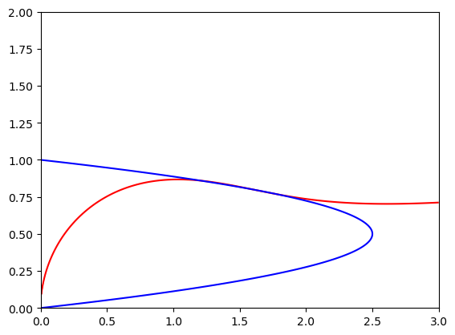

```python
alpha = 8
beta = 1.5
epsilon = 0.05
delta = 0.1
n = 2

dBdt = lambda B,S: B*(alpha*S - B)*(S**n + B**n) - alpha*beta*S*B**n
dSdt = lambda B,S: epsilon*(S*(1 - S) - delta*B)

b = np.linspace(0, 3, 500)
s = np.linspace(0, 2, 500)
B,S = np.meshgrid(b,s)
Y = dBdt(B, S)
Z = dSdt(B, S)
plt.contour(B, S, Y, levels=0,colors='r')
plt.contour(B, S, Z, levels=0,colors='b')
plt.show()
```

Taking a closer look of the plot to observe the steady states:

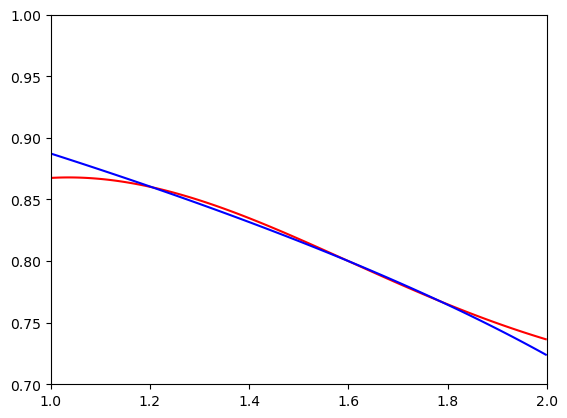

```python
b = np.linspace(1, 2, 500)
s = np.linspace(0.7, 1, 500)
B,S = np.meshgrid(b,s)
Y = dBdt(B, S)
Z = dSdt(B, S)
plt.contour(B, S, Y, levels=0,colors='r')
plt.contour(B, S, Z, levels=0,colors='b')
plt.show()
```

## Finding the steady states at the intersection of the nullclines

Finding a solution of the equations $dBdt(B, S) = dSdt(B, S) = 0$ using a numerical method with starting guess $v0$:

```python
# point 1
F = lambda v: np.array([dBdt(*v), dSdt(*v)])
v0 = [1.2, 0.85]
v1 = spo.fsolve(F, v0)
print("First steady state: ", v1)
```

```
First steady state:  [1.20514474 0.85984097]
```

```python
# point 2
v0 = [1.6, 0.8]
v2 = spo.fsolve(F, v0)
print("Second steady state: ", v2)
```

```
Second steady state:  [1.6 0.8]
```

```python
# point 3
v0 = [1.7, 0.7]
v3 = spo.fsolve(F, v0)
print("Third steady state: ", v3)
```

```
Third steady state:  [1.78461676 0.76746649]
```

## Approximating the solutions of the system of ODEs for the given parameter values

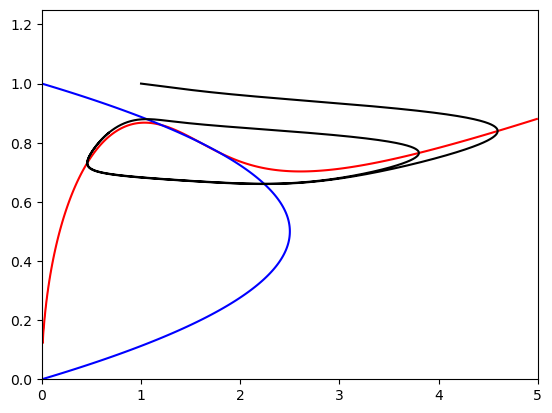

```python
t = np.linspace(0, 200, 10000)
u0 = [1, 1]
G = lambda v,t: np.array([v[0]*(1 - v[0]/alpha/v[1]) - beta*v[0]**n/(v[1]**n + v[0]**n), epsilon*(v[1]*(1 - v[1]) - delta*v[0])])
sol = spi.odeint(G, u0, t)

b = np.linspace(0, 5, 500)
s = np.linspace(0, 1.25, 500)
B,S = np.meshgrid(b,s)
Y = dBdt(B, S)
Z = dSdt(B, S)
plt.contour(B, S, Y, levels=0,colors='r')
plt.contour(B, S, Z, levels=0,colors='b')
plt.plot(sol[:,0], sol[:,1], 'k')
plt.show()
```

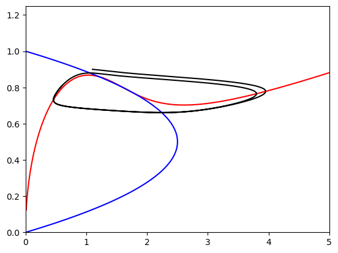

```python
t = np.linspace(0, 200, 10000)
u0 = [1.1, 0.9]
G = lambda v,t: np.array([v[0]*(1 - v[0]/alpha/v[1]) - beta*v[0]**n/(v[1]**n + v[0]**n), epsilon*(v[1]*(1 - v[1]) - delta*v[0])])
sol = spi.odeint(G, u0, t)

b = np.linspace(0, 5, 500)
s = np.linspace(0, 1.25, 500)
B,S = np.meshgrid(b,s)
Y = dBdt(B, S)
Z = dSdt(B, S)
plt.contour(B, S, Y, levels=0,colors='r')
plt.contour(B, S, Z, levels=0,colors='b')
plt.plot(sol[:,0], sol[:,1], 'k')
plt.show()
```

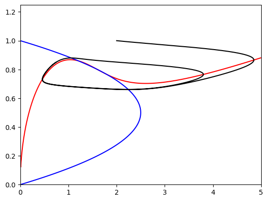

```python
t = np.linspace(0, 200, 10000)
u0 = [2, 1]
G = lambda v,t: np.array([v[0]*(1 - v[0]/alpha/v[1]) - beta*v[0]**n/(v[1]**n + v[0]**n), epsilon*(v[1]*(1 - v[1]) - delta*v[0])])
sol = spi.odeint(G, u0, t)

b = np.linspace(0, 5, 500)
s = np.linspace(0, 1.25, 500)
B,S = np.meshgrid(b,s)
Y = dBdt(B, S)
Z = dSdt(B, S)
plt.contour(B, S, Y, levels=0,colors='r')
plt.contour(B, S, Z, levels=0,colors='b')
plt.plot(sol[:,0], sol[:,1], 'k')
plt.show()
```

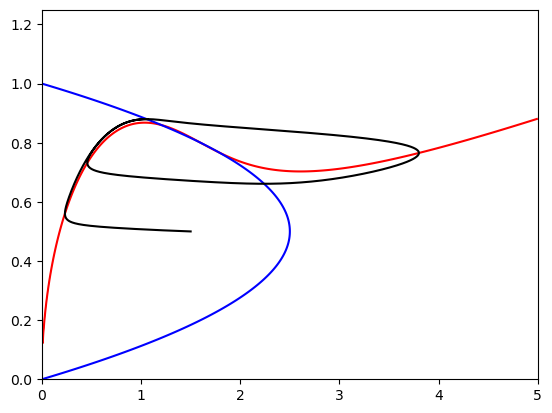

```python
t = np.linspace(0, 200, 10000)
u0 = [1.5, 0.5]
G = lambda v,t: np.array([v[0]*(1 - v[0]/alpha/v[1]) - beta*v[0]**n/(v[1]**n + v[0]**n), epsilon*(v[1]*(1 - v[1]) - delta*v[0])])
sol = spi.odeint(G, u0, t)

b = np.linspace(0, 5, 500)
s = np.linspace(0, 1.25, 500)
B,S = np.meshgrid(b,s)
Y = dBdt(B, S)
Z = dSdt(B, S)
plt.contour(B, S, Y, levels=0,colors='r')
plt.contour(B, S, Z, levels=0,colors='b')
plt.plot(sol[:,0], sol[:,1], 'k')
plt.show()
```

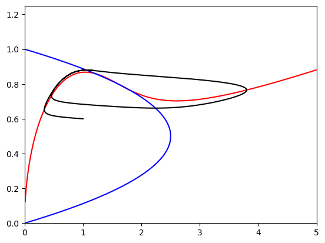

```python
t = np.linspace(0, 200, 10000)
u0 = [1, 0.6]
G = lambda v,t: np.array([v[0]*(1 - v[0]/alpha/v[1]) - beta*v[0]**n/(v[1]**n + v[0]**n), epsilon*(v[1]*(1 - v[1]) - delta*v[0])])
sol = spi.odeint(G, u0, t)

b = np.linspace(0, 5, 500)
s = np.linspace(0, 1.25, 500)
B,S = np.meshgrid(b,s)
Y = dBdt(B, S)
Z = dSdt(B, S)
plt.contour(B, S, Y, levels=0,colors='r')
plt.contour(B, S, Z, levels=0,colors='b')
plt.plot(sol[:,0], sol[:,1], 'k')
plt.show()
```

## Observing how the behaviour of the system changes

We choose to observe the behaviour of the system when we increment and decrement the values of $\beta$ and $\delta$, and $n$:

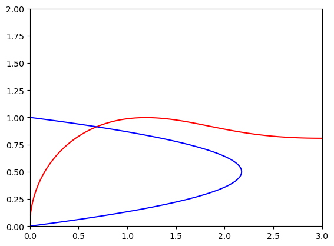

```python
beta = 1.725
delta = 0.115

b = np.linspace(0, 3, 500)
s = np.linspace(0, 2, 500)
B,S = np.meshgrid(b,s)
Y = dBdt(B, S)
Z = dSdt(B, S)
plt.contour(B, S, Y, levels=0,colors='r')
plt.contour(B, S, Z, levels=0,colors='b')
plt.show()
```

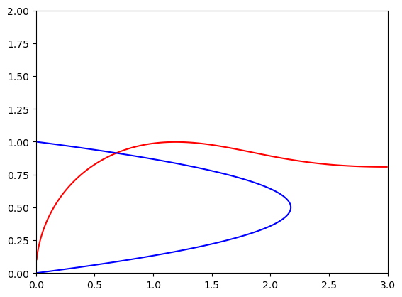

```python
beta = 1.725
delta = 0.115

b = np.linspace(0, 3, 500)
s = np.linspace(0, 2, 500)
B,S = np.meshgrid(b,s)
Y = dBdt(B, S)
Z = dSdt(B, S)
plt.contour(B, S, Y, levels=0,colors='r')
plt.contour(B, S, Z, levels=0,colors='b')
plt.show()
```

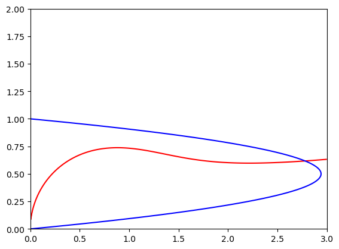

```python
beta = 1.275
delta = 0.085

b = np.linspace(0, 3, 500)
s = np.linspace(0, 2, 500)
B,S = np.meshgrid(b,s)
Y = dBdt(B, S)
Z = dSdt(B, S)
plt.contour(B, S, Y, levels=0,colors='r')
plt.contour(B, S, Z, levels=0,colors='b')
plt.show()
```

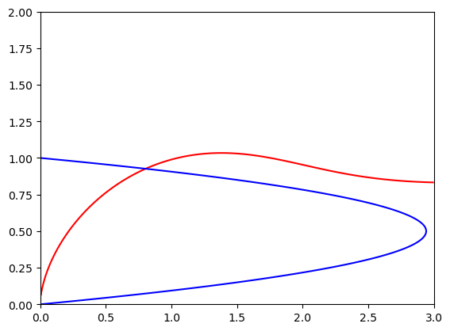

```python
beta = 1.725
delta = 0.085
n = 2.4

b = np.linspace(0, 3, 500)
s = np.linspace(0, 2, 500)
B,S = np.meshgrid(b,s)
Y = dBdt(B, S)
Z = dSdt(B, S)
plt.contour(B, S, Y, levels=0,colors='r')
plt.contour(B, S, Z, levels=0,colors='b')
plt.show()
```

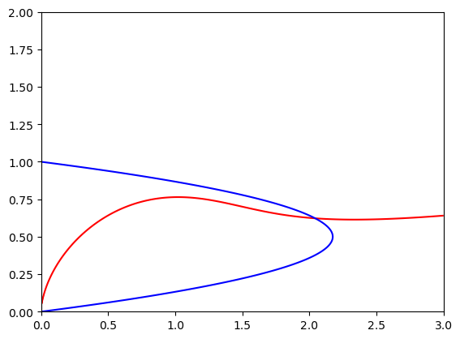

```python
beta = 1.275
delta = 0.115

b = np.linspace(0, 3, 500)
s = np.linspace(0, 2, 500)
B,S = np.meshgrid(b,s)
Y = dBdt(B, S)
Z = dSdt(B, S)
plt.contour(B, S, Y, levels=0,colors='r')
plt.contour(B, S, Z, levels=0,colors='b')
plt.show()
```

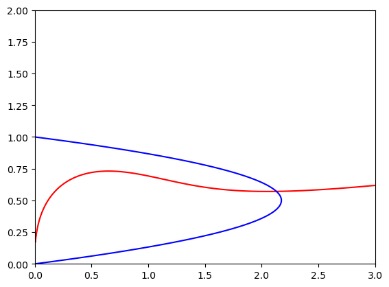

```python
beta = 1.275
delta = 0.115
n = 1.6

b = np.linspace(0, 3, 500)
s = np.linspace(0, 2, 500)
B,S = np.meshgrid(b,s)
Y = dBdt(B, S)
Z = dSdt(B, S)
plt.contour(B, S, Y, levels=0,colors='r')
plt.contour(B, S, Z, levels=0,colors='b')
plt.show()
```

Based on the changes made, we can see some quantitative and qualitative changes to the system depending on the parameter values.

## Bibliography

[1] Donald Ludwig, Dixon D Jones, Crawford S Holling, et al. “Qualitative analysis of insect outbreak systems: the spruce budworm and forest”. In: Journal of animal ecology 47.1 (1978), pp. 315–332.

[2] Robert M May. “Thresholds and breakpoints in ecosystems with a multiplicity of stable states”. In: Nature 269.5628 (1977), pp. 471–477.

[3] DG Mott. “The forest and the spruce budworm”. In: The Memoirs of the Entomological Society of Canada (link) 95.S31 (1963), pp. 189–202.